# 🌌 Classifying Stars, Galaxies & Quasars 🔭

📊 Numerical Features vs Class

- **`alpha`:** Statistically significant but practically weak differences, indicating limited standalone classification power.
- **`delta`:** Shows significant class differences, with `QSO` having higher average values, but effect size remains small to moderate.
- **`u`:** Clearly differs across classes; `GALAXY` tends to have higher values while `STAR` shows wider variability.
- **`g`:** `GALAXY` and `QSO` are concentrated at higher values, while `STAR` has a broader and lower range.
- **`r`:** `QSO` tends toward higher values, while `STAR` shows wider and lower-value distribution.
- **`i`:** `QSO` is concentrated at higher values, while `STAR` has the broadest distribution range.
- **`z`:** `QSO` generally has higher values, while `STAR` exhibits the widest spread.
- **`redshift`:** Provides the strongest class separation, with `QSO` much higher than `GALAXY` and `STAR`.

**Key Insight:** Most numerical features show statistically significant class differences, but `redshift` is the most discriminative feature for separating celestial object classes, especially `QSO`.

**Distribution of Spectral_Type by Class**

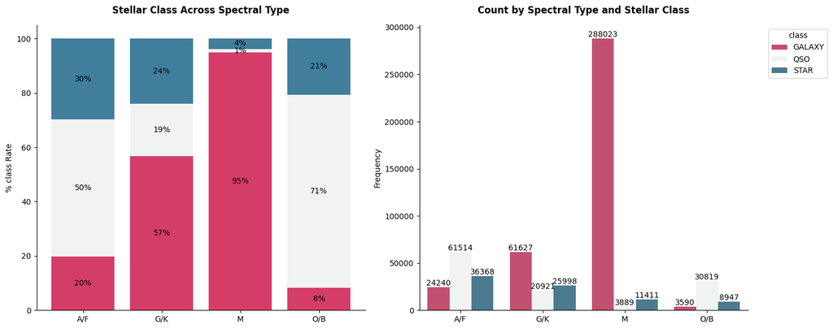

```
2026-06-07 08:35:28 | INFO     | Chi-Square Test of Independence: 'spectral_type' vs. 'class'...
2026-06-07 08:35:28 | INFO     | Chi-squared statistic: 318015.509
2026-06-07 08:35:28 | INFO     | Degrees of freedom: 6
2026-06-07 08:35:28 | INFO     | p-value: 0.000000
2026-06-07 08:35:28 | INFO     | Result: p-value < 0.05 → Reject H₀
2026-06-07 08:35:28 | INFO     | Variables 'spectral_type' and 'class' are statistically associated.
2026-06-07 08:35:28 | DEBUG    | Displaying standardized residuals heatmap.
```

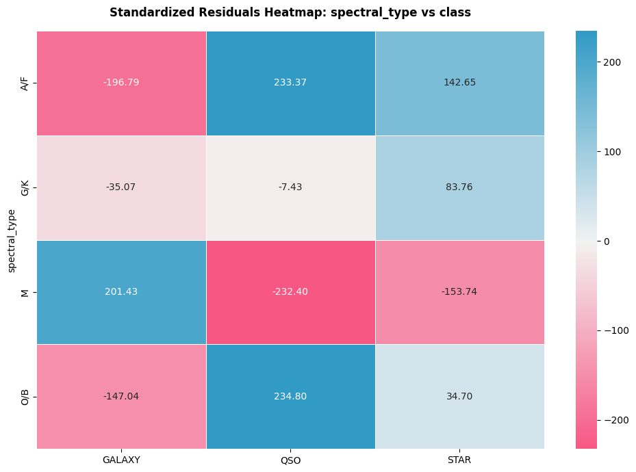

**Distribution of Galaxy_Population by Class**

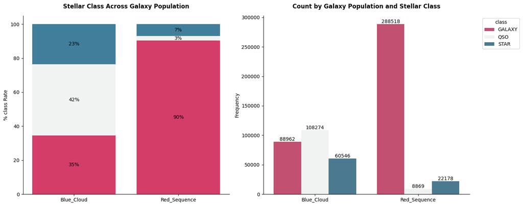

```
2026-06-07 08:35:29 | INFO     | Chi-Square Test of Independence: 'galaxy_population' vs. 'class'...
2026-06-07 08:35:30 | INFO     | Chi-squared statistic: 203361.480
2026-06-07 08:35:30 | INFO     | Degrees of freedom: 2
2026-06-07 08:35:30 | INFO     | p-value: 0.000000
2026-06-07 08:35:30 | INFO     | Result: p-value < 0.05 → Reject H₀
2026-06-07 08:35:30 | INFO     | Variables 'galaxy_population' and 'class' are statistically associated.
2026-06-07 08:35:30 | DEBUG    | Displaying standardized residuals heatmap.
```

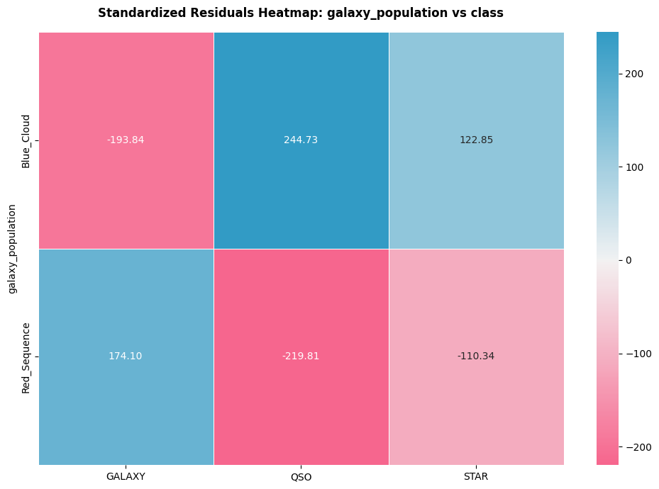

```python
def bivariate_percent_plot(cat: str, target_feature: str,
                           df: pd.DataFrame, figsize=(15, 6), order=None) -> None:
    """
    Plot the relationship between a categorical feature and the target variable.

    This function displays:
    - A stacked bar chart showing percentage distribution of target classes.
    - A count plot showing absolute frequencies.
    - A Chi-Square test for feature–target dependence.

    Parameters
    ----------
    cat : str
        Categorical feature name.

    target_feature : str
        Target variable name.

    df : pd.DataFrame
        Input dataset.

    figsize : tuple, optional
        Figure size (width, height). Default is (15, 6).

    order : list, optional
        Custom order of categories on x-axis.

    Returns
    -------
    None
    """

    display(HTML(f"<h2 style='text-align:center; font-size:22px; color:blue;'><b>Distribution of {cat.title()} by {target_feature.title()}</b></h2>"))
    fig, ax = plt.subplots(nrows=1, ncols=2, sharey=False, figsize=figsize)

    # Data processing
    grouped = df.groupby([cat, target_feature]).size().unstack(fill_value=0)

    # Define a fixed hue order (adjust if needed)
    target_order = [c for c in ["Yes", "No"] if c in grouped.columns]

    # Fallback if the labels are 0/1 or have different names
    if not target_order:
        target_order = list(grouped.columns)

    # Calculate percentages row-wise and reorder columns by target_order
    percentages = grouped.div(grouped.sum(axis=1), axis=0)[target_order] * 100

    # Define X-axis category order
    if order is not None:
        percentages = percentages.loc[order]
        labels = order
    else:
        labels = percentages.index.tolist()

    # Consistent color palette for both charts
    base_colors = color(n_colors=len(target_order))
    color_map = dict(zip(target_order, base_colors))

    # Plot 1: Stacked bar chart (percentage)
    bottom = np.zeros(len(percentages))
    for cls in target_order:
        ax[0].bar(percentages.index.astype(str), percentages[cls].values, bottom=bottom,
                  label=cls, color=color_map[cls])
        bottom += percentages[cls].values

    # Add percentage labels
    for container in ax[0].containers:
        ax[0].bar_label(container, fmt="%1.0f%%", label_type="center",
                        fontsize=10, color="black")

    ax[0].set_title(f"Stellar Class Across {cat.replace('_', ' ').title()}", fontsize=12, weight="bold", pad=15)
    ax[0].set_xlabel("")
    ax[0].set_ylabel(f"% {target_feature} Rate", fontsize=10)
    sns.despine(left=False, bottom=False, ax=ax[0])
    ax[0].legend().remove()

    # Plot 2: Count plot (using same color_map + hue_order)
    sns.countplot(data=df, hue=target_feature, x=cat,
                  order=labels, hue_order=target_order,
                  palette=color_map, ax=ax[1])

    for container in ax[1].containers:
        ax[1].bar_label(container, fmt="%d", label_type="edge",
                        fontsize=10, color="black")

    ax[1].set_title(f"Count by {cat.replace('_', ' ').title()} and Stellar Class", fontsize=12, weight="bold", pad=15)
    ax[1].set_xlabel("")
    ax[1].set_ylabel("Frequency")
    ax[1].legend(title=target_feature, bbox_to_anchor=(1.05, 1), loc="upper left")
    sns.despine(left=False, bottom=False, ax=ax[1])
    plt.tight_layout()
    plt.show()

    # Chi-Square Test
    cal_ChiSquare(cat_feature=cat, target_feature=target_feature, df=df, show_residuals=True)

# Run for all categorical features
for feature in cat_features:
    bivariate_percent_plot(cat=feature, target_feature=CFG.TARGET_FEATURE, df=df_train)
```

📊 Categorical Features vs Class

- **`spectral_type`:** Strongly associated with celestial object classes, making it a highly informative categorical feature for classification.
- **`galaxy_population`:** Strongly associated with celestial object classes, with `QSO` linked to `Blue_Cloud` and `GALAXY` more associated with `Red_Sequence`.

**Key Insight:** Both categorical features show strong statistical association with the target class and provide useful signal for improving classification performance.

# Overall Picture

# Overall Picture

📊 Consolidated Feature Impact Summary – Celestial Object Classification

| Feature | Summary |
| --- | --- |
| **redshift** | **Most discriminative feature** — strongly separates `QSO` from `GALAXY` and `STAR`. |
| **spectral_type** | **Highly informative categorical feature** — strongly associated with celestial object classes. |
| **galaxy_population** | **Strong categorical signal** — `QSO` aligns with `Blue_Cloud`, while `GALAXY` is linked to `Red_Sequence`. |
| **u** | **Strong photometric feature** — shows clear distribution differences across classes with high variability in `STAR`. |
| **g** | **Strong photometric feature** — `GALAXY` and `QSO` tend toward higher values than `STAR`. |
| **r** | **Moderately strong feature** — `QSO` generally exhibits higher values while `STAR` has broader spread. |
| **i** | **Moderately strong feature** — `QSO` concentrates at higher values while `STAR` shows the broadest distribution. |
| **z** | **Moderately strong feature** — significant separation observed with wider spread in `STAR`. |
| **delta** | **Supporting positional feature** — statistically different across classes but with limited practical effect size. |
| **alpha** | **Weak standalone feature** — statistically significant but provides limited discriminative power. |

# Astronomy-Specific Analysis

# Astronomy-Specific Analysis

## Sky Distribution of Objects¶

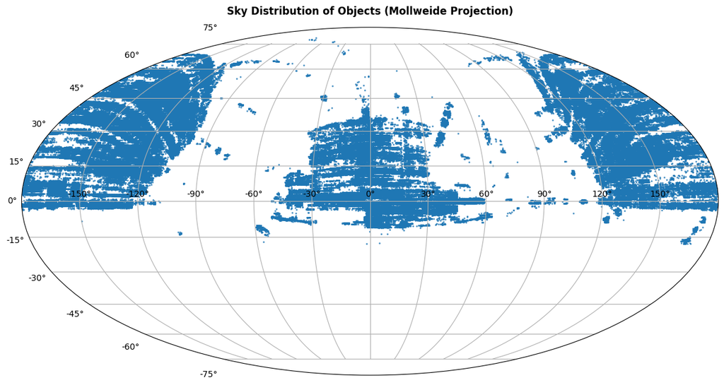

```python
coords = SkyCoord(
    ra = df_train["alpha"].values*u.deg,
    dec = df_train["delta"].values*u.deg,
    frame="icrs")

fig = plt.figure(figsize=(12, 10))
ax = fig.add_subplot(111, projection="mollweide")

ax.scatter(
    coords.ra.wrap_at(180 * u.degree).radian,
    coords.dec.radian,
    s=1.5,
    alpha=0.6)

ax.grid(True)
ax.set_title("Sky Distribution of Objects (Mollweide Projection)", fontsize=12, pad=15, weight="bold")
plt.tight_layout()
plt.show()
```

## Objects in Galactic Coordinates

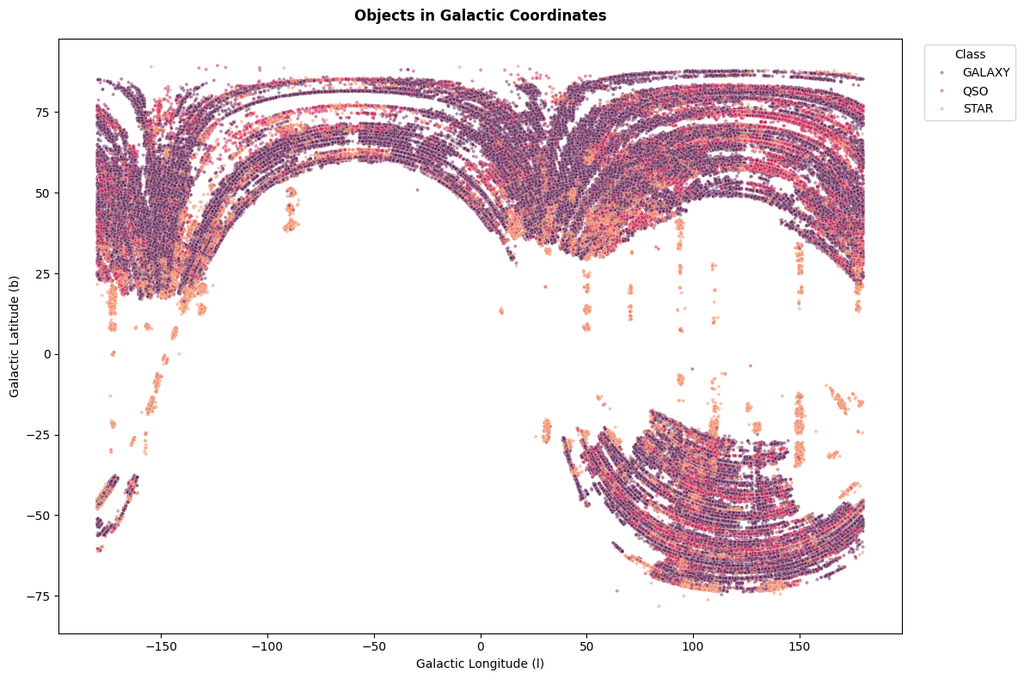

```python
coords = SkyCoord(
    ra = df_train["alpha"].values * u.deg,
    dec = df_train["delta"].values * u.deg,
    frame="icrs")
galactic = coords.galactic

plt.figure(figsize=(12, 8))
sns.scatterplot(
    x=galactic.l.wrap_at(180*u.degree).degree,
    y=galactic.b.degree,
    hue=df_train["class"],
    palette="rocket",
    alpha=0.5,
    s=8)
plt.title("Objects in Galactic Coordinates", fontsize=12, pad=15, weight="bold")
plt.xlabel("Galactic Longitude (l)")
plt.ylabel("Galactic Latitude (b)")
plt.legend(title="Class", bbox_to_anchor=(1.02, 1), loc="upper left")
plt.tight_layout()
plt.show()
```

## Color-Magnitude Diagram (u-g vs r)

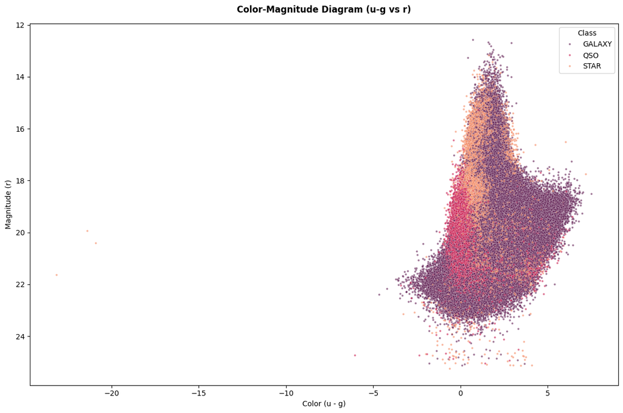

```python
df_temp = df_train.copy()
df_temp["u_g"] = df_temp["u"] - df_temp["g"]

plt.figure(figsize=(12, 8))
sns.scatterplot(
    data=df_temp,
    x="u_g",
    y="r",
    hue="class",
    alpha=0.6,
    s=8,
    palette="rocket")
plt.title("Color-Magnitude Diagram (u-g vs r)", fontsize=12, pad=15, weight="bold")
plt.xlabel("Color (u - g)")
plt.ylabel("Magnitude (r)")
plt.legend(title="Class")
plt.gca().invert_yaxis()
plt.tight_layout()
plt.show()
```

## Sky Position (α, δ) Colored by Class (Size = Redshift)

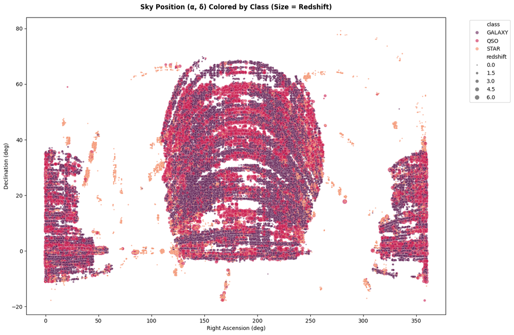

```python
plt.figure(figsize=(14, 10))
sns.scatterplot(
    data=df_train,
    x="alpha",
    y="delta",
    hue="class",
    size=df_train["redshift"].clip(lower=0),
    sizes=(5, 80),
    alpha=0.6,
    palette="rocket")

plt.title("Sky Position (α, δ) Colored by Class (Size = Redshift)", fontsize=12, pad=15, weight="bold")
plt.xlabel("Right Ascension (deg)")
plt.ylabel("Declination (deg)")
plt.legend(bbox_to_anchor=(1.05, 1), loc="upper left")
plt.show()
```

# Feature Engineering

# Feature Engineering

```python
class FeatureEngineering():
    """
    Feature engineering pipeline for celestial object classification.

    Includes:
    - Astronomy color index features
    - Statistical signals from original dataset
    - Digit-based numerical decomposition
    - Numerical-to-categorical conversion
    """

    def __init__(self, target, categorical_features, numerical_features, BASE):
        """
        Initialize feature engineering configuration.
        """
        self.target = target
        self.categorical_features = categorical_features
        self.numerical_features = numerical_features
        self.BASE = BASE

    def color_features(self, df):
        """
        Create astronomy color index features
        using differences between photometric bands.
        """
        df = df.copy()

        # Standard SDSS color indices
        df["u_g"] = df["u"] - df["g"]
        df["g_r"] = df["g"] - df["r"]
        df["r_i"] = df["r"] - df["i"]
        df["i_z"] = df["i"] - df["z"]
        df["u_r"] = df["u"] - df["r"]

        return df

    def signal_from_original(self, df, df_original):
        """
        Generate statistical aggregation features
        from the original dataset.
        """
        df = df.copy()

        for col in self.categorical_features:

            # Skip missing columns
            if col not in df_original.columns:
                continue

            # Group statistics
            means = df_original.groupby(col)[self.target].mean()
            medians = df_original.groupby(col)[self.target].median()
            counts = df_original.groupby(col)[self.target].count()

            # Map aggregated statistics
            df[f"{col}_mean"] = df[col].map(means).fillna(df_original[self.target].mean())
            df[f"{col}_median"] = df[col].map(medians).fillna(df_original[self.target].median())
            df[f"{col}_count"] = df[col].map(counts).fillna(0)

        return df

    def extract_digit_positions(self, df):
        """
        Extract unit, tens, and hundreds digits
        from numerical features.
        """
        df = df.copy()

        for col in self.numerical_features:

            # Convert values safely to integer
            col_numeric = pd.to_numeric(df[col], errors="coerce").fillna(0).astype(int)

            # Zero padding for stable indexing
            col_str = col_numeric.astype(str).str.zfill(5)

            # Digit extraction
            df[f"{col}_digit_units"] = col_str.str[-1].astype(int)
            df[f"{col}_digit_tens"] = col_str.str[-2].astype(int)

            if col_str.str.len().max() >= 3:
                df[f"{col}_digit_hundreds"] = col_str.str[-3].astype(int)

        return df

    def encode_all_as_categorical(self, df):
        """
        Convert numerical features into
        categorical/string representations.
        """
        df = df.copy()

        for col in self.numerical_features:
            df[f"{col}_cat"] = df[col].astype(str)

        return df

    def transform(self, df, df_original, methods=None):
        """
        Apply selected feature engineering methods sequentially.
        """
        df = df.copy()

        # Default pipeline
        if methods is None:
            methods = [
                "color_features",
                "signal_from_original",
                "extract_digit_positions",
                "encode_all_as_categorical"
            ]

        for method_name in methods:
            # Check method existence
            if hasattr(self, method_name):
                method = getattr(self, method_name)
                # Methods requiring original dataset
                if method_name in ["signal_from_original"]:
                    df = method(df, df_original)
                # Standard transformation methods
                else:
                    df = method(df)
            else:
                logger.warning(f"Warning: Method {method_name} not found!")

        return df
```

```python
BASE = df_train.columns.drop(CFG.TARGET_FEATURE).to_list()
fe = FeatureEngineering(target=CFG.TARGET_FEATURE, categorical_features=cat_features,
                        numerical_features=num_features, BASE=BASE)

le = LabelEncoder()
df_original[CFG.TARGET_FEATURE] = le.fit_transform(df_original[CFG.TARGET_FEATURE])

df_train_final = fe.transform(df=df_train, df_original=df_original,
                                  methods=["color_features",
                                          "signal_from_original",
                                           "extract_digit_positions",
                                           "encode_all_as_categorical"])

df_test_final = fe.transform(df=df_test, df_original=df_original,
                                  methods=["color_features",
                                           "signal_from_original",
                                           "extract_digit_positions",
                                           "encode_all_as_categorical"])

stat_cols = [col for col in df_train_final.columns if col.endswith(("_mean", "_median", "_count"))]

for col in stat_cols:
    df_train_final[col] = pd.to_numeric(df_train_final[col], errors="coerce").astype("float32")
    df_test_final[col] = pd.to_numeric(df_test_final[col], errors="coerce").astype("float32")

cat_features = df_test_final.select_dtypes(include=["category", "object"]).columns.tolist()
num_features = df_test_final.select_dtypes(include=["int", "float"]).columns.tolist()

# Reduce memory and convert to category
df_train_final = CFG.reduce_mem_usage(cols=num_features, df=df_train_final)
df_test_final = CFG.reduce_mem_usage(cols=num_features, df=df_test_final)

df_train_final = CFG.convert_cat(features=cat_features, df=df_train_final)
df_test_final = CFG.convert_cat(features=cat_features, df=df_test_final)

datasets = {"Train": df_train_final, "Test": df_test_final}

# Display information about the DataFrames
for name, df in datasets.items():
    logger.info(f"{name} Data Info")
    df.info()
```

```
2026-06-07 08:36:27 | INFO     | Train Data Info
<class 'pandas.DataFrame'>
RangeIndex: 577347 entries, 0 to 577346
Data columns (total 54 columns):
 #   Column                    Non-Null Count   Dtype
---  ------                    --------------   -----
 0   alpha                     577347 non-null  float32
 1   delta                     577347 non-null  float32
 2   u                         577347 non-null  float32
 3   g                         577347 non-null  float32
 4   r                         577347 non-null  float32
 5   i                         577347 non-null  float32
 6   z                         577347 non-null  float32
 7   redshift                  577347 non-null  float32
 8   spectral_type             577347 non-null  category
```

[output cut: 108 more lines]

# Model Training

# Model Training

```python
le = LabelEncoder()
df_train_final[CFG.TARGET_FEATURE] = le.fit_transform(df_train_final[CFG.TARGET_FEATURE])

X = df_train_final.drop([CFG.TARGET_FEATURE], axis=1).copy()
y = df_train_final[CFG.TARGET_FEATURE].copy()
X_test = df_test_final.copy()
```

## CatBoostClassifier

```python
cat_params = {
    "iterations": 10000,
    "learning_rate": 0.03,
    "depth": 8,
    "l2_leaf_reg": 5,
    "loss_function": "MultiClass",
    "auto_class_weights": "Balanced",
    "eval_metric": "TotalF1",
    "random_seed": CFG.RANDOM_STATE,
    "verbose": 0,
    "early_stopping_rounds": 500,
    "task_type": "GPU",
    "cat_features": cat_features
}

skf = StratifiedKFold(n_splits=CFG.N_SPLIT_KFOLD, shuffle=True, random_state=CFG.RANDOM_STATE)

n_classes = len(np.unique(y))
oof_labels = np.zeros(len(X), dtype=int)
y_test_probs = np.zeros((len(X_test), n_classes))
fold_scores = []
feature_importances = []

for fold, (train_idx, val_idx) in enumerate(skf.split(X, y)):
    X_train, X_val = X.iloc[train_idx], X.iloc[val_idx]
    y_train, y_val = y.iloc[train_idx], y.iloc[val_idx]

    model = CatBoostClassifier(**cat_params)
    model.fit(X_train, y_train, eval_set=(X_val, y_val), use_best_model=True)

    val_labels = model.predict(X_val).ravel()
    oof_labels[val_idx] = val_labels

    test_probs = model.predict_proba(X_test)
    y_test_probs += test_probs / CFG.N_SPLIT_KFOLD

    fold_score = balanced_accuracy_score(y_val, val_labels)
    fold_scores.append(fold_score)
    importance = model.get_feature_importance()
    feature_importances.append(importance)
    logger.info(f"Fold {fold + 1} balanced accuracy: {fold_score:.5f}")
    del model
    gc.collect()
    cp.get_default_memory_pool().free_all_blocks()

total_oof_score = balanced_accuracy_score(y, oof_labels)
logger.info("*"*80)
logger.info(f"Mean Fold Score: {np.mean(fold_scores):.5f} (+/- {np.std(fold_scores):.5f})")
logger.info(f"OOF Balanced Accuracy: {total_oof_score:.5f}")
```

```
2026-06-07 08:39:11 | INFO     | Fold 1 balanced accuracy: 0.96519
2026-06-07 08:41:23 | INFO     | Fold 2 balanced accuracy: 0.96415
2026-06-07 08:43:54 | INFO     | Fold 3 balanced accuracy: 0.96442
2026-06-07 08:46:20 | INFO     | Fold 4 balanced accuracy: 0.96412
2026-06-07 08:48:16 | INFO     | Fold 5 balanced accuracy: 0.96409
2026-06-07 08:48:16 | INFO     | ********************************************************************************
2026-06-07 08:48:16 | INFO     | Mean Fold Score: 0.96439 (+/- 0.00042)
2026-06-07 08:48:16 | INFO     | OOF Balanced Accuracy: 0.96439
```

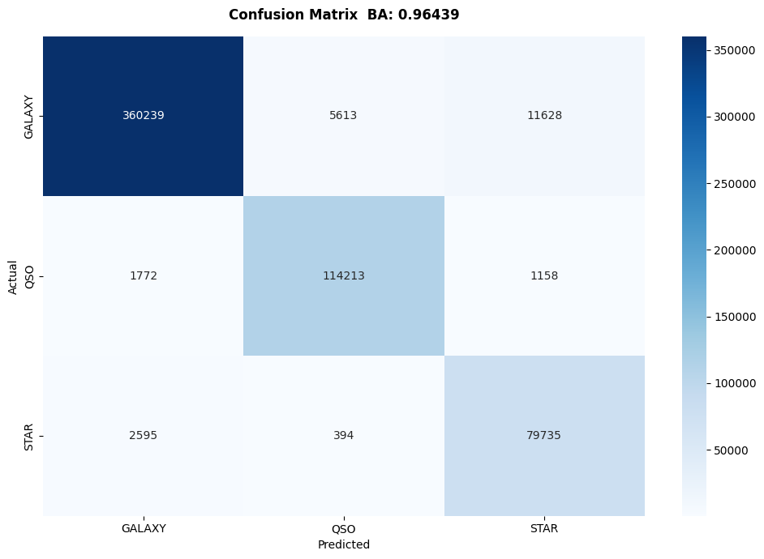

```python
labels = ["GALAXY", "QSO", "STAR"]
labels = np.unique(y)
display_labels = le.inverse_transform(labels)
cm = confusion_matrix(y.values, oof_labels, labels=labels)
ba = balanced_accuracy_score(y.values, oof_labels)

plt.figure(figsize=(10, 7))

sns.heatmap(
    cm,
    annot=True,
    fmt="d",
    cmap="Blues",
    xticklabels=display_labels,
    yticklabels=display_labels,
    cbar=True
)

plt.title(f"Confusion Matrix  BA: {ba:.5f}", fontsize=12, pad=15, weight="bold")
plt.xlabel("Predicted")
plt.ylabel("Actual")
plt.tight_layout()
plt.show()
```

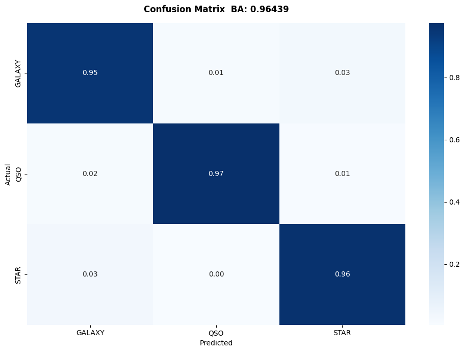

```python
plt.figure(figsize=(10, 7))
cm = confusion_matrix(y.values, oof_labels, labels=labels, normalize="true")
sns.heatmap(
    cm,
    annot=True,
    fmt=".2f",
    cmap="Blues",
    xticklabels=display_labels,
    yticklabels=display_labels,
    cbar=True
)

plt.title(f"Confusion Matrix  BA: {ba:.5f}", fontsize=12, pad=15, weight="bold")
plt.xlabel("Predicted")
plt.ylabel("Actual")
plt.tight_layout()
plt.show()
```

```python
logger.info("\n" + str(classification_report(y.values, oof_labels)))
```

```
2026-06-07 08:48:18 | INFO     |
              precision    recall  f1-score   support

           0       0.99      0.95      0.97    377480
           1       0.95      0.97      0.96    117143
           2       0.86      0.96      0.91     82724

    accuracy                           0.96    577347
   macro avg       0.93      0.96      0.95    577347
weighted avg       0.96      0.96      0.96    577347
```

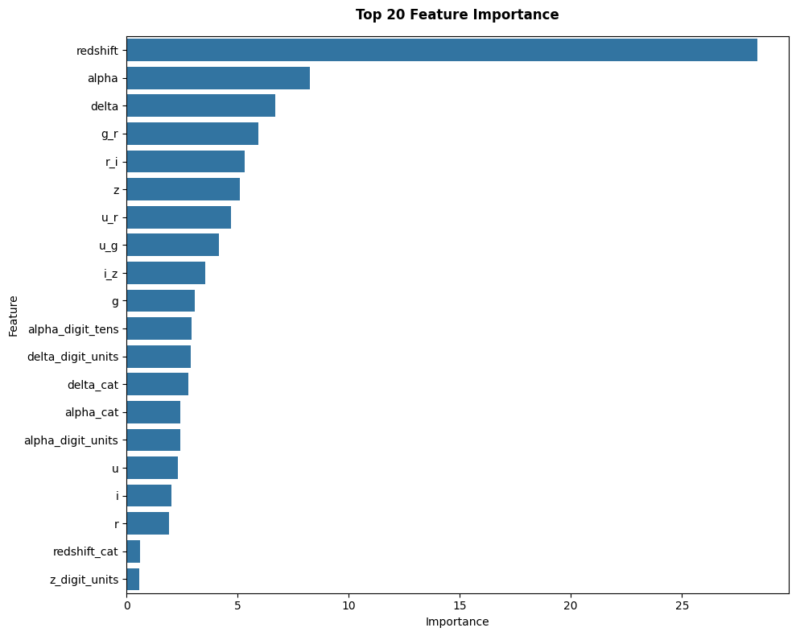

```python
df_importance = pd.DataFrame({
    "Feature": X.columns,
    "Importance": np.mean(feature_importances, axis=0)
}).sort_values(by="Importance", ascending=False).head(20)

plt.figure(figsize=(10, 8))
plt.title("Top 20 Feature Importance", fontsize=12, pad=15, weight="bold")
ax = sns.barplot(x="Importance", y="Feature", data=df_importance)
plt.tight_layout()
plt.show()
```

```python
y_test_labels = np.argmax(y_test_probs, axis=1)
y_test_labels_final = le.inverse_transform(y_test_labels)

submission = pd.DataFrame({
    "id": list_test_id,
    "class": y_test_labels_final
})

submission.to_csv("submission.csv", index=False)
submission.head()
```

|  | id | class |
| --- | --- | --- |
| 0 | 577347 | GALAXY |
| 1 | 577348 | GALAXY |
| 2 | 577349 | GALAXY |
| 3 | 577350 | STAR |
| 4 | 577351 | GALAXY |

# Recommendation

# Recommendation

📊 Feature Importance Insights

#### Acknowledgements

[@sakuno -](https://www.kaggle.com/sakuno) [Stellar Class 🌌 Astro EDA & CV Catboost](https://www.kaggle.com/code/sakuno/stellar-class-astro-eda-cv-catboost)

#### References

- [Kaggle Playground Series – S6E6](https://www.kaggle.com/competitions/playground-series-s6e6)

#### Citation

Walter Reade and Elizabeth Park. **Predicting Stellar Class**  
[Kaggle Competition Playground Series S6E6, 2026.](https://www.kaggle.com/competitions/playground-series-s6e6)

# 🙏 Thanks for Reading 🚀

Upvote if you liked it 🙌😊